# PenEstim

Simulation Study

Author

Affiliation

Nicolas Kubista

Harvard University

Published

April 24, 2024

# Family Simulation 1

We simulate 3000 families, our of which we subset the families to only include those families where the proband was a carrier of the PV. The simulation was done using the PedUtils package. The penetrance for non-carriers is based on the SEER penetrances in the PanelPRO Database. For carriers we specify a Weibull penetrance with the following parameters:

- Alpha = 2.5
- Beta = 50
- Delta = 0
- Gamma = 1

For men:

- Alpha = 2.5
- Beta = 80
- Delta = 0
- Gamma = 1

Censoring is based on a
$$N(85,10)$$
. The simulated age of death is centered at 85 with a standard deviation of 10, but values above ageMax (default = 94) are re-simulated to be centered around ageMax - 15.

```r
# Function to describe the families
describeFamilies <- function(fams, cancer, gene) {
  # Validate and translate cancer type
  if (!cancer %in% CANCER_NAME_MAP$long) {
    stop("Cancer type '", cancer, "' is not supported. Please choose from the supported list.")
  }

  # Get the abbreviation for the cancer type
  cancer_index <- which(CANCER_NAME_MAP$long == cancer)
  cancer_short <- CANCER_NAME_MAP$short[cancer_index]

  # Construct column names based on cancer type and gene input
  aff_col_name <- paste0("isAff", cancer_short)
  age_col_name <- paste0("Age", cancer_short)

  # Initialize counters and vectors for storing data
  affectedFamilies = 0
  affectedProbands = 0
  famSizes = c()
  geneFamilies = 0
  geneProbands = 0
  curAges = c()
  cancerAges = c()
  pbCancerAges = c()
  pbCurAges = c()
  pbCancerAgesFemale = c()
  affectedFemaleProbands = 0
  geneFemaleProbands = 0
  cancerAgesFemale = c()
  total_individuals = 0
  gene_individuals = 0

  # Process each family
  for(i in 1:length(fams)){
    f = fams[[i]]
    sizeOfFamily = nrow(f)
    total_individuals = total_individuals + sizeOfFamily
    famSizes = c(famSizes, sizeOfFamily)
    curAges = c(curAges, f$CurAge)
    f = f %>% dplyr::filter(!!rlang::sym(aff_col_name) == 1, isProband == 0)
    cancerAges <- c(cancerAges, f[[age_col_name]])
    ff = fams[[i]] %>% dplyr::filter(!!rlang::sym(gene) == 1, !!rlang::sym(aff_col_name) == 1)
    gene_individuals = gene_individuals + nrow(ff)
    cancerAgesFemale <- c(cancerAgesFemale, ff[[age_col_name]])

    if(nrow(f)>0){
      affectedFamilies = affectedFamilies + 1
    }
    geneFams = fams[[i]] %>% dplyr::filter(isProband == 0, !!rlang::sym(gene) == 1)
    if(nrow(geneFams) > 0){
     geneFamilies = geneFamilies + 1
    }

    pb <- fams[[i]] %>% dplyr::filter(isProband == 1)
    pbfemale <- fams[[i]] %>% dplyr::filter(isProband == 1, Sex == 0)

    if (nrow(pbfemale) > 0) {
      pbCancerAgesFemale <- c(pbCancerAgesFemale, pbfemale[[age_col_name]])
      if (any(pbfemale[[aff_col_name]] == 1)){
        affectedFemaleProbands <- affectedFemaleProbands + 1
      }
      if (!is.na(pbfemale[[gene]])){
        if (any(pbfemale[[gene]] == 1)){
          geneFemaleProbands <- geneFemaleProbands + 1
        }
      }
    }

    pbCancerAges <- c(pbCancerAges, pb[[age_col_name]])
    pbCurAges <- c(pbCurAges, pb$CurAge)

    if (any(pb[[aff_col_name]] == 1)){
      affectedProbands <- affectedProbands + 1
    }

    if (!is.na(pb[[gene]])){
      if (any(pb[[gene]] == 1)){
        geneProbands <- geneProbands + 1
      }
    }
  }

  print(paste0("Number of families: ", length(fams)))
  print(paste0("Total Individuals: ", total_individuals))
  print(paste0("Average family size: ", mean(famSizes)))
  print("Summary of family sizes")
  print(summary(famSizes))
  print("Summary of Current Age for all family members")
  print(summary(curAges))
  print("Summary of Current Age for probands")
  print(summary(pbCurAges))

  print(paste0("Number of families with affected individuals (", cancer, "): ",
               affectedFamilies))
  print(paste0("Number of families with affected probands (", cancer, "): ",
               affectedProbands))
  print(paste0("Number of families with affected female probands (", cancer, "): ",
               affectedFemaleProbands))
  print(paste0("Number of families with relatives with PV (and not the proband) (", gene, "): ", geneFamilies))
  print(paste0("Number of probands with PV (", gene, "): ", geneProbands))
  print(paste0("Number of female probands with PV (", gene, "): ",
               geneFemaleProbands))
  print(paste0("Number of individuals with PV (", gene, "): ", gene_individuals))

  print("Summary of Cancer Age of (female) probands")
  print(summary(pbCancerAgesFemale))

  print("Summary of Cancer Age in affected (non-proband) individuals")
  print(summary(cancerAges))
}
```

```
character(0)
```

```
[1] "Number of families: 544"
[1] "Total Individuals: 15373"
[1] "Average family size: 28.2591911764706"
[1] "Summary of family sizes"
   Min. 1st Qu.  Median    Mean 3rd Qu.    Max.
  22.00   25.00   27.00   28.26   31.00   50.00
[1] "Summary of Current Age for all family members"
   Min. 1st Qu.  Median    Mean 3rd Qu.    Max.
   2.00   15.00   41.00   42.27   70.00   94.00
[1] "Summary of Current Age for probands"
   Min. 1st Qu.  Median    Mean 3rd Qu.    Max.
   16.0    35.0    40.0    40.2    45.0    64.0
[1] "Number of families with affected individuals (Breast): 543"
[1] "Number of families with affected probands (Breast): 175"
[1] "Number of families with affected female probands (Breast): 126"
[1] "Number of families with relatives with PV (and not the proband) (BRCA1): 0"
[1] "Number of probands with PV (BRCA1): 544"
[1] "Number of female probands with PV (BRCA1): 294"
[1] "Number of individuals with PV (BRCA1): 175"
[1] "Summary of Cancer Age of (female) probands"
   Min. 1st Qu.  Median    Mean 3rd Qu.    Max.
   2.00   28.00   36.00   33.79   41.00   55.00
[1] "Summary of Cancer Age in affected (non-proband) individuals"
   Min. 1st Qu.  Median    Mean 3rd Qu.    Max.
   3.00   28.00   42.00   42.27   56.00   93.00
   Min. 1st Qu.  Median    Mean 3rd Qu.    Max.
   3.00   28.00   42.00   42.27   56.00   93.00
```

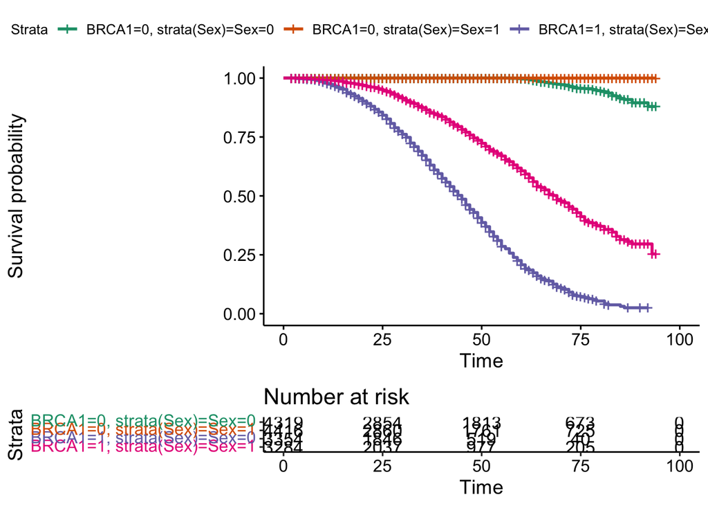

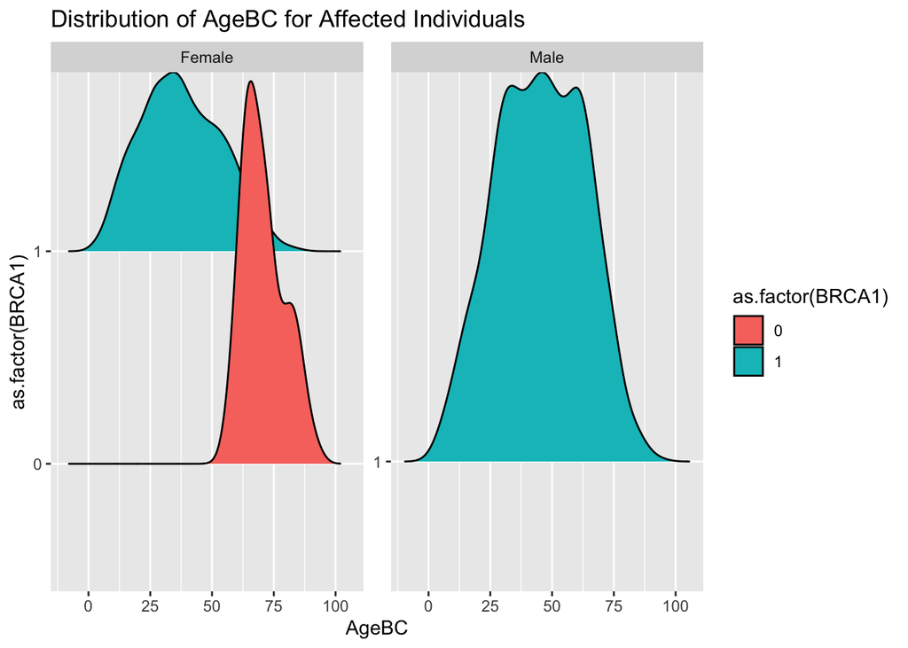

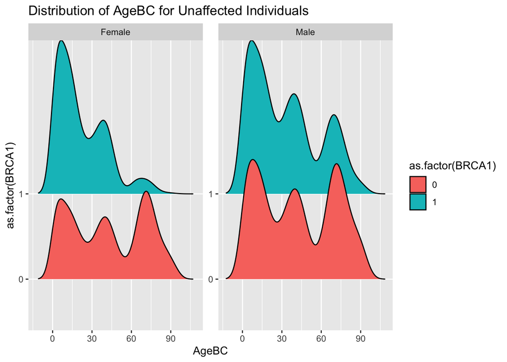

# Family Simulation 2

```
character(0)
```

```
[1] "Number of families: 580"
[1] "Total Individuals: 16392"
[1] "Average family size: 28.2620689655172"
[1] "Summary of family sizes"
   Min. 1st Qu.  Median    Mean 3rd Qu.    Max.
  22.00   25.00   27.00   28.26   31.00   52.00
[1] "Summary of Current Age for all family members"
   Min. 1st Qu.  Median    Mean 3rd Qu.    Max.
   2.00   15.00   41.00   42.39   69.00   94.00
[1] "Summary of Current Age for probands"
   Min. 1st Qu.  Median    Mean 3rd Qu.    Max.
  14.00   36.00   41.00   40.57   46.00   66.00
[1] "Number of families with affected individuals (Breast): 496"
[1] "Number of families with affected probands (Breast): 26"
[1] "Number of families with affected female probands (Breast): 21"
[1] "Number of families with relatives with PV (and not the proband) (BRCA1): 0"
[1] "Number of probands with PV (BRCA1): 580"
[1] "Number of female probands with PV (BRCA1): 286"
[1] "Number of individuals with PV (BRCA1): 26"
[1] "Summary of Cancer Age of (female) probands"
   Min. 1st Qu.  Median    Mean 3rd Qu.    Max.
  19.00   35.00   40.00   40.10   44.75   66.00
[1] "Summary of Cancer Age in affected (non-proband) individuals"
   Min. 1st Qu.  Median    Mean 3rd Qu.    Max.
  22.00   47.00   57.50   57.21   67.00   94.00
   Min. 1st Qu.  Median    Mean 3rd Qu.    Max.
  22.00   47.00   57.50   57.21   67.00   94.00
```

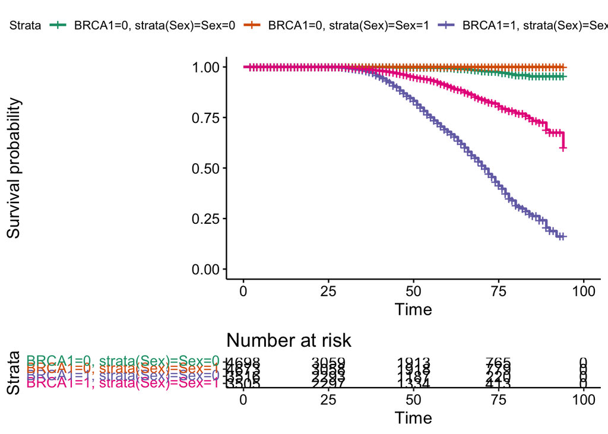

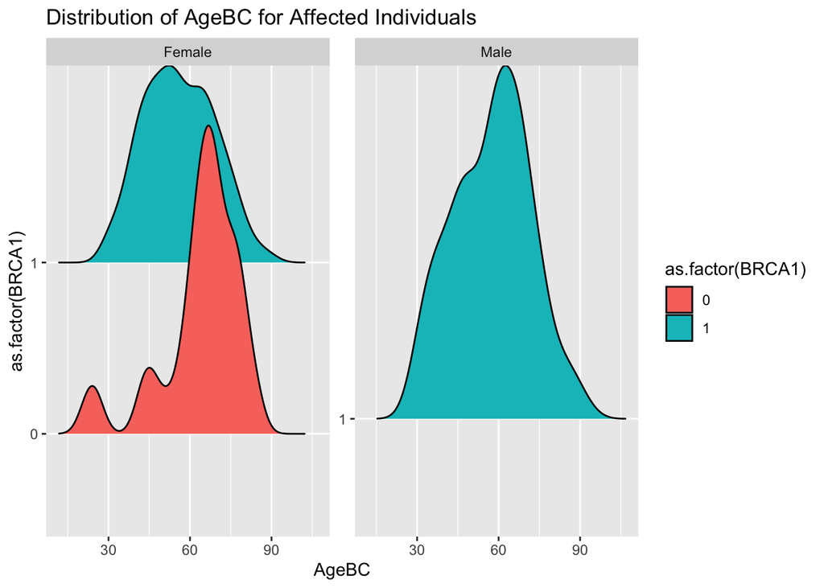

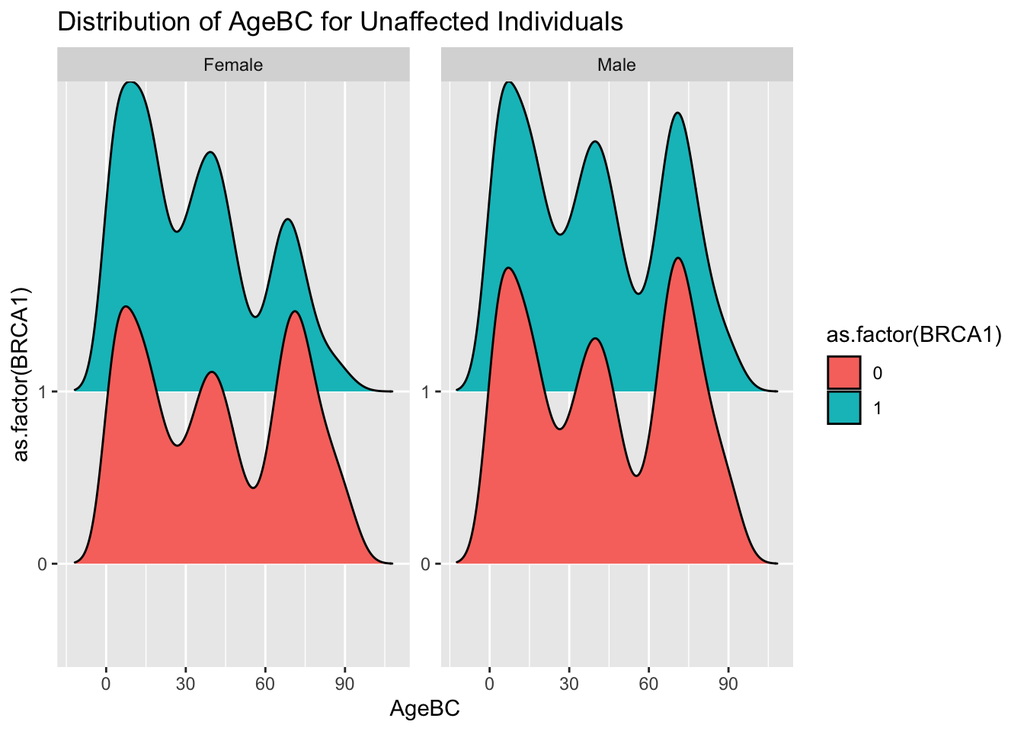

# Estimation

The likelihood model in `penet.fn` is based on the Weibull distribution for carriers and, per default, the SEER peentrance data for non-carriers. For an individual $i$, the model considers the following parameters:

- $\alpha$: Shape parameter of the Weibull distribution
- $\beta$: Scale parameter of the Weibull distribution
- $\delta$: Shift parameter for the age in the Weibull function
- $\gamma$: Asymptote parameter to adjust the scale of the Weibull function
- $\text{age}_i$: Age of the individual $i$
- $\text{aff}_i$: Affection status (1 if affected, 0 otherwise)

An indiviudal that develops cancer at $\text{age}_i$ contributes a term $f$ to the likelihood, which is just the density of the Weibull in our model. The contribution from an individual whose survival time is censored at is the survival probability $S_i = 1 - F$ where $F$ is corresponding cumulative distribution function of the Weibull.

$$f(x; \alpha, \beta, \delta, \gamma) =
\begin{cases}
\gamma \left( \frac{\alpha}{\beta} \left( \frac{x - \delta}{\beta} \right)^{\alpha - 1} e^{-\left( \frac{x - \delta}{\beta} \right)^\alpha } \right), & x \geq \delta \\
0, & x < \delta
\end{cases}$$

$$F(x; \alpha, \beta, \delta, \gamma) =
\begin{cases}
\gamma \left( 1 - e^{-\left( \frac{x - \delta}{\beta} \right)^\alpha } \right), & x \geq \delta \\
0, & x < \delta
\end{cases}$$

The survival probability for individual $i$ is calculated as:
$$S_i = 1 - pweibull(\text{age}_i - \delta, \alpha, \beta) \times \gamma$$
where pweibull is the CDF of the Weibull.

To simpflify the estimation we fix $\gamma = 1$ and $\delta = 0$.

The density (for affected individuals) is calculated as:

$$c.pen = dweibull(\text{age}_i - \delta, \alpha, \beta) \times \gamma$$
. This gives:

$$\text{carrierLik}_i =
\begin{cases}
\text{S}_i & \text{aff}_i = 0 \\
\text{c.pen} & \text{aff}_i = 1
\end{cases}$$

The baseline risk $\text{SEER\_baseline}_i$ is derived from SEER data. For more details see seperate documentation.

## MCMC with Adaptive MH - Families 1

The Adaptive Metropolis-Hastings (MH) algorithm improves the efficiency of the standard Metropolis-Hastings algorithm by adapting the proposal distribution based on the history of the accepted samples. This then adapts the coveriance matrix.

The covariance matrix $\Sigma$ is adapted based on the covariance of the accepted samples.

```
Rejection rates:  0.8637
```

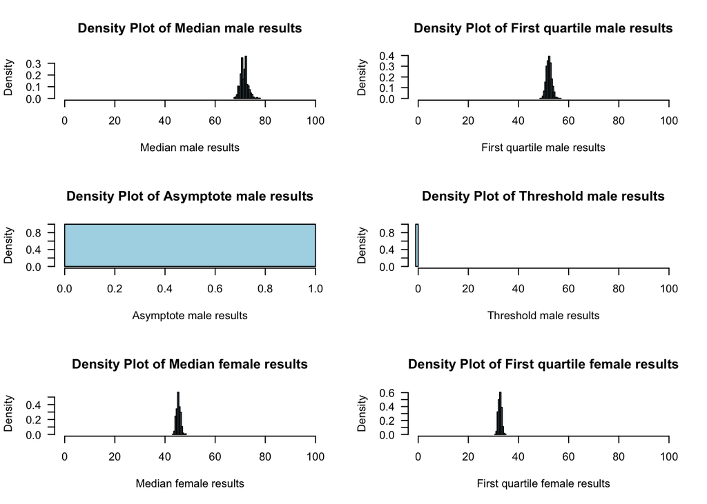

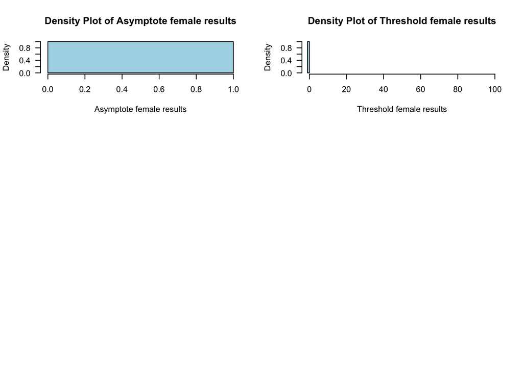

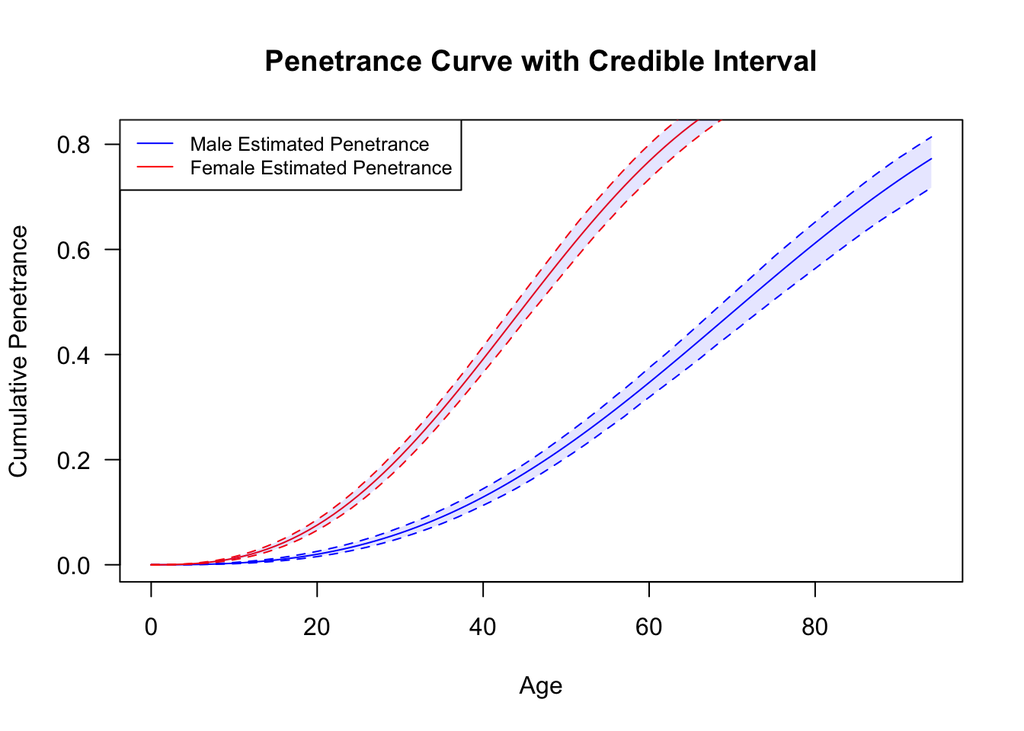

```
     user    system   elapsed
    0.894     0.231 22122.224
```

```r
dat <- simfamilies_sim4

# Data Prep
for (i in seq_along(dat)) {
    if ("ID" %in% colnames(dat[[i]])) {
        colnames(dat[[i]])[colnames(dat[[i]]) == "PedigreeID"] <- "FamilyID"
    }
}

#  Data Prep
for (i in seq_along(dat)) {
    if ("ID" %in% colnames(dat[[i]])) {
        colnames(dat[[i]])[colnames(dat[[i]]) == "ID"] <- "SubjectID"
    }
}

for (i in seq_along(dat)) {
    # Add a new column "PedigreeID" with the list number
    dat[[i]]$PedigreeID <- i
}

# Exploring different priors
prior_params_BRCA1 <- list(
    asymptote = list(g1 = 900, g2 = 100),
    threshold = list(min = 15, max = 40),
    median = list(m1 = 2, m2 = 2),
    first_quartile = list(q1 = 6, q2 = 3)
)

# Run Estimation procedure with default prior setting
# Main Estimation for Female
system.time(out_sim_5.3 <- PenEstim_v3(
    data = dat,
    cancer_type = "Breast", gene_input = "BRCA1", n_chains = 1, n_iter_per_chain = 10000,
    prior_params = prior_params_BRCA1, af = 0.1, burn_in = 0.1, median_max = FALSE
))
```

```r
save(out_sim_5.3, file = "out_sim_5.3.Rdata")

# print summary stats
out_sim_5.3$summary_stats
```

```
  Median_Male    Median_Female   Threshold_Male Threshold_Female
 Min.   :67.62   Min.   :43.27   Min.   :0      Min.   :0
 1st Qu.:70.58   1st Qu.:44.83   1st Qu.:0      1st Qu.:0
 Median :71.53   Median :45.33   Median :0      Median :0
 Mean   :71.55   Mean   :45.35   Mean   :0      Mean   :0
 3rd Qu.:72.32   3rd Qu.:45.85   3rd Qu.:0      3rd Qu.:0
 Max.   :77.82   Max.   :48.47   Max.   :0      Max.   :0
 First_Quartile_Male First_Quartile_Female Asymptote_Male Asymptote_Female
 Min.   :48.71       Min.   :30.74         Min.   :1      Min.   :1
 1st Qu.:51.40       1st Qu.:32.18         1st Qu.:1      1st Qu.:1
 Median :52.09       Median :32.57         Median :1      Median :1
 Mean   :52.13       Mean   :32.60         Mean   :1      Mean   :1
 3rd Qu.:52.79       3rd Qu.:33.02         3rd Qu.:1      3rd Qu.:1
 Max.   :56.95       Max.   :35.00         Max.   :1      Max.   :1
```

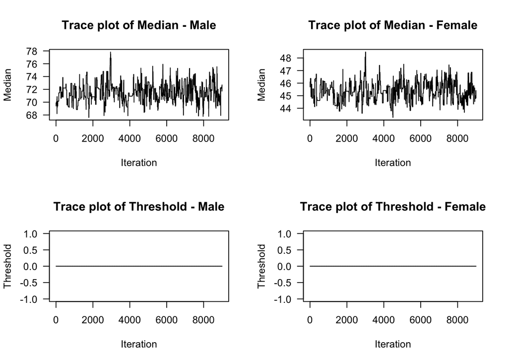

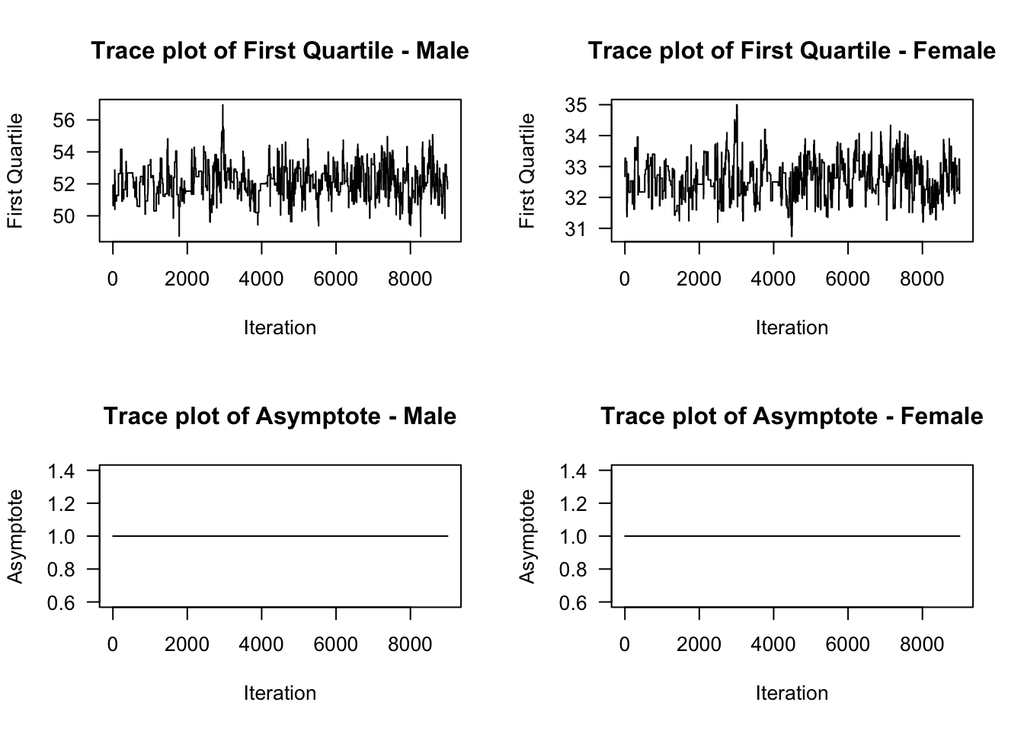

```r
plot_traceSingle(out_sim_5.3$results[[1]])
```

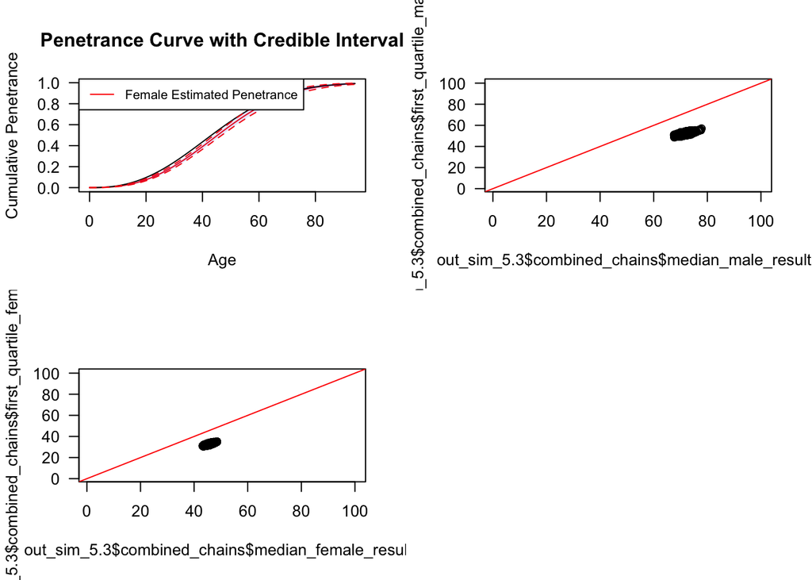

```r
plot_penetrance_sim(out_sim_5.3$combined_chains, prob = 0.95, max_age = 94,"Female",2.5,50,0,1)

# plot the scatterplot with the median and first quartile
plot(out_sim_5.3$combined_chains$median_male_results, out_sim_5.3$combined_chains$first_quartile_male_results, xlim = c(1,100), ylim = c(1,100))
abline(a=0, b=1, col="red") # This draws a red line with slope 1 passing through the origin
plot(out_sim_5.3$combined_chains$median_female_results, out_sim_5.3$combined_chains$first_quartile_female_results, xlim = c(1,100), ylim = c(1,100))
abline(a=0, b=1, col="red") # This draws a red line with slope 1 passing through the origin
```

## MCMC with Adaptive MH - Families 2

```
Rejection rates:  0.9489
```

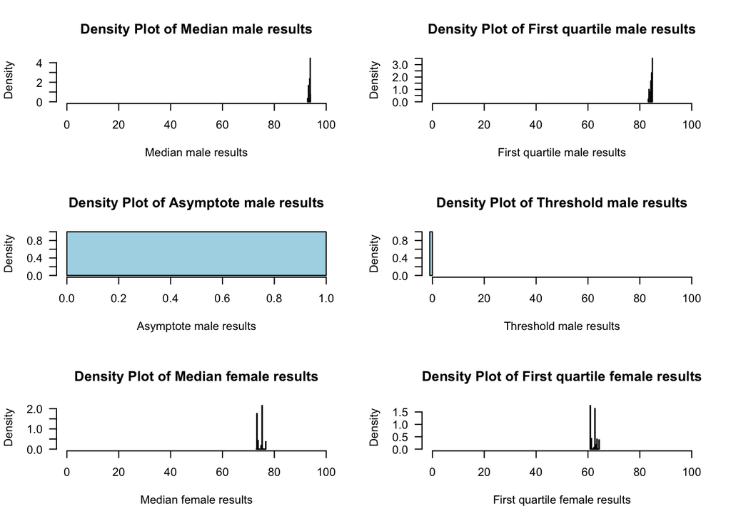

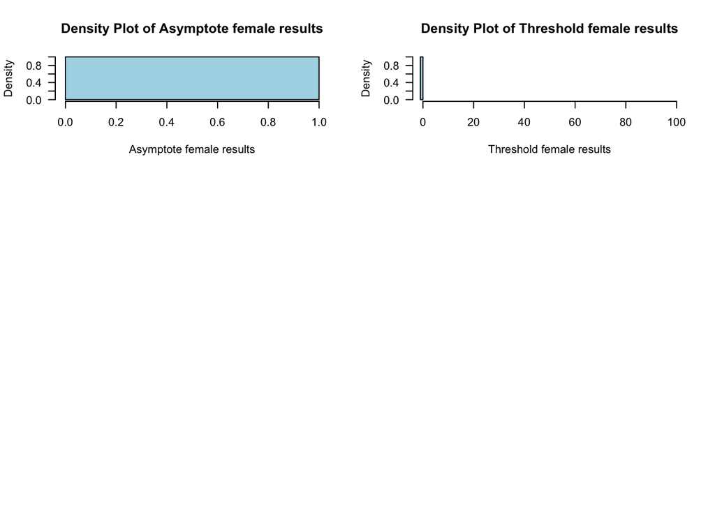

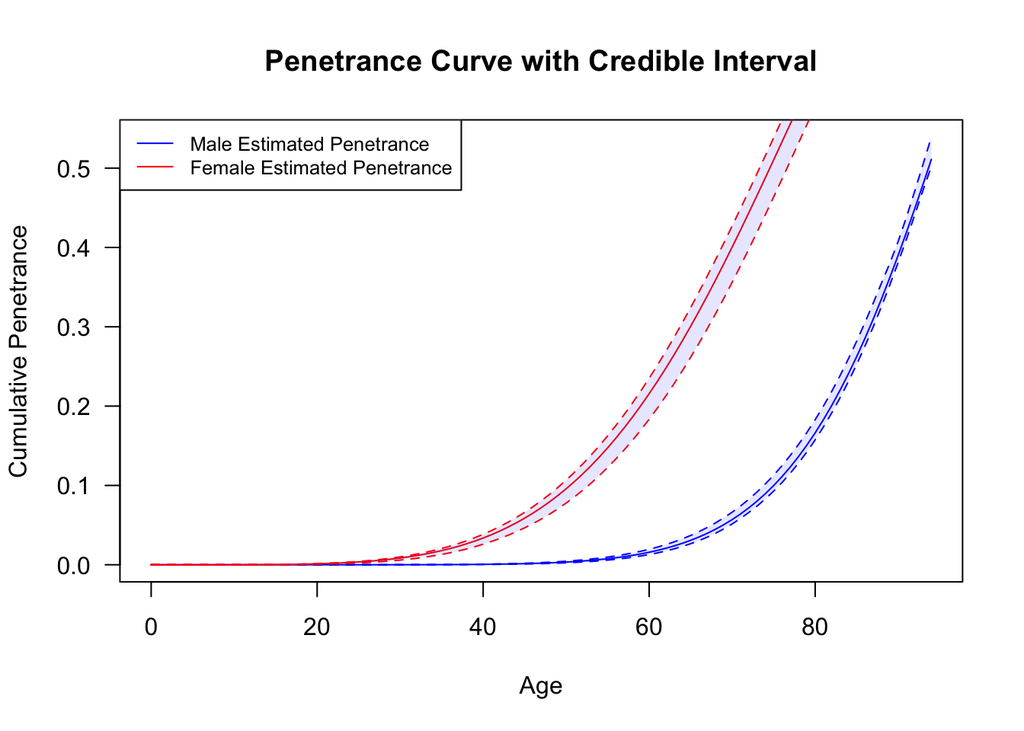

```
     user    system   elapsed
    0.432     0.205 24596.808
```

```r
dat <- simfamilies_sim4.2

# Data Prep
for (i in seq_along(dat)) {
    if ("ID" %in% colnames(dat[[i]])) {
        colnames(dat[[i]])[colnames(dat[[i]]) == "PedigreeID"] <- "FamilyID"
    }
}

#  Data Prep
for (i in seq_along(dat)) {
    if ("ID" %in% colnames(dat[[i]])) {
        colnames(dat[[i]])[colnames(dat[[i]]) == "ID"] <- "SubjectID"
    }
}

for (i in seq_along(dat)) {
    # Add a new column "PedigreeID" with the list number
    dat[[i]]$PedigreeID <- i
}

# Exploring different priors
prior_params_BRCA1 <- list(
    asymptote = list(g1 = 900, g2 = 100),
    threshold = list(min = 15, max = 40),
    median = list(m1 = 2, m2 = 2),
    first_quartile = list(q1 = 6, q2 = 3)
)

# Run Estimation procedure with default prior setting
# Main Estimation for Female
system.time(out_sim_5.4 <- PenEstim_v3(
    data = dat,
    cancer_type = "Breast", gene_input = "BRCA1", n_chains = 1, n_iter_per_chain = 10000,
    prior_params = prior_params_BRCA1, af = 0.1, burn_in = 0.1, median_max = FALSE
))
```

```r
save(out_sim_5.4, file = "out_sim_5.4.Rdata")

# print summary stats
out_sim_5.4$summary_stats
```

```
  Median_Male    Median_Female   Threshold_Male Threshold_Female
 Min.   :92.86   Min.   :73.06   Min.   :0      Min.   :0
 1st Qu.:93.68   1st Qu.:73.30   1st Qu.:0      1st Qu.:0
 Median :93.81   Median :75.23   Median :0      Median :0
 Mean   :93.65   Mean   :74.54   Mean   :0      Mean   :0
 3rd Qu.:93.87   3rd Qu.:75.29   3rd Qu.:0      3rd Qu.:0
 Max.   :93.93   Max.   :76.61   Max.   :0      Max.   :0
 First_Quartile_Male First_Quartile_Female Asymptote_Male Asymptote_Female
 Min.   :83.23       Min.   :60.90         Min.   :1      Min.   :1
 1st Qu.:84.23       1st Qu.:60.90         1st Qu.:1      1st Qu.:1
 Median :84.54       Median :62.63         Median :1      Median :1
 Mean   :84.44       Mean   :62.16         Mean   :1      Mean   :1
 3rd Qu.:84.89       3rd Qu.:62.75         3rd Qu.:1      3rd Qu.:1
 Max.   :84.89       Max.   :64.33         Max.   :1      Max.   :1
```

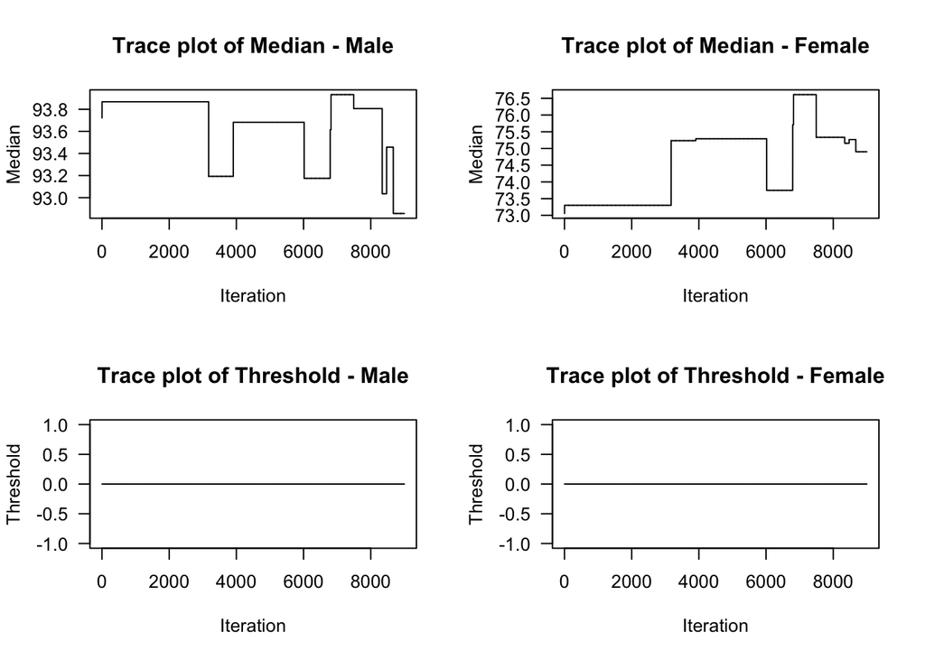

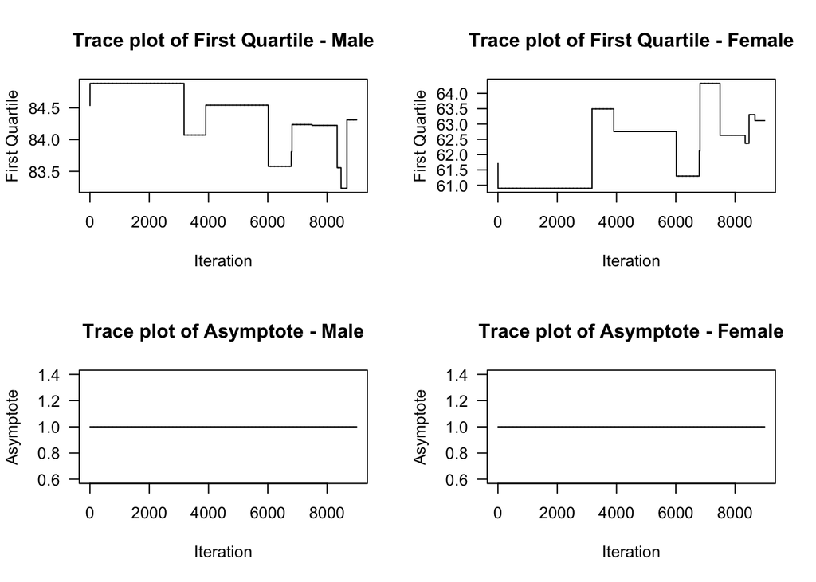

```r
plot_traceSingle(out_sim_5.4$results[[1]])
```

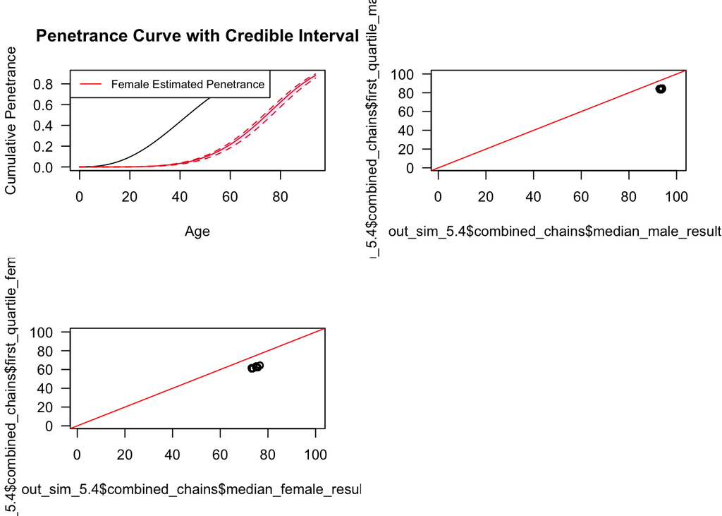

```r
plot_penetrance_sim(out_sim_5.4$combined_chains, prob = 0.95, max_age = 94,"Female",2.5,50,0,1)

# plot the scatterplot with the median and first quartile
plot(out_sim_5.4$combined_chains$median_male_results, out_sim_5.4$combined_chains$first_quartile_male_results, xlim = c(1,100), ylim = c(1,100))
abline(a=0, b=1, col="red") # This draws a red line with slope 1 passing through the origin
plot(out_sim_5.4$combined_chains$median_female_results, out_sim_5.4$combined_chains$first_quartile_female_results, xlim = c(1,100), ylim = c(1,100))
abline(a=0, b=1, col="red") # This draws a red line with slope 1 passing through the origin
```